# Project: noshowappointments-kagglev2-may-2016

- Introduction
- Data Wrangling
- Exploratory Data Analysis
- Conclusions

## Introduction

This dataset shows the appointmentID, patientID,gender, schedule and appointment days,as well as the medical issues of over a hundred and ten thousand patients. The information is collected from medical appointments in Brazil,and is focused on whether or not patients show up for their appointment.

## *Questions :*

1 How many "Yes" and "No" No-show reponses was received? And can patients' gender be used to predict the overall appointment show-up responses?

2 What medical issues of patients are important inorder to predict whether a patient shows-up or not?

```python
# This cell is to set up import statements for all of the packages that I
#   plan to use.
import pandas as pd
import matplotlib.pyplot as plt
import numpy as np
import seaborn as sns
%matplotlib inline
```

## Data Wrangling

### General Properties

```python
# Load your data and print out a few lines. Perform operations to inspect data
#   types and look for instances of missing or possibly errant data.
df = pd.read_csv('noshowappointments-kagglev2-may-2016.csv')
df.tail(10)
```

|  | PatientId | AppointmentID | Gender | ScheduledDay | AppointmentDay | Age | Neighbourhood | Scholarship | Hipertension | Diabetes | Alcoholism | Handcap | SMS_received | No-show |
| --- | --- | --- | --- | --- | --- | --- | --- | --- | --- | --- | --- | --- | --- | --- |
| 110517 | 5.574942e+12 | 5780122 | F | 2016-06-07T07:38:34Z | 2016-06-07T00:00:00Z | 19 | MARIA ORTIZ | 0 | 0 | 0 | 0 | 0 | 0 | No |
| 110518 | 7.263315e+13 | 5630375 | F | 2016-04-27T15:15:06Z | 2016-06-07T00:00:00Z | 50 | MARIA ORTIZ | 0 | 0 | 0 | 0 | 0 | 1 | No |
| 110519 | 6.542388e+13 | 5630447 | F | 2016-04-27T15:23:14Z | 2016-06-07T00:00:00Z | 22 | MARIA ORTIZ | 0 | 0 | 0 | 0 | 0 | 1 | No |
| 110520 | 9.969977e+14 | 5650534 | F | 2016-05-03T07:51:47Z | 2016-06-07T00:00:00Z | 42 | MARIA ORTIZ | 0 | 0 | 0 | 0 | 0 | 1 | No |
| 110521 | 3.635534e+13 | 5651072 | F | 2016-05-03T08:23:40Z | 2016-06-07T00:00:00Z | 53 | MARIA ORTIZ | 0 | 0 | 0 | 0 | 0 | 1 | No |
| 110522 | 2.572134e+12 | 5651768 | F | 2016-05-03T09:15:35Z | 2016-06-07T00:00:00Z | 56 | MARIA ORTIZ | 0 | 0 | 0 | 0 | 0 | 1 | No |
| 110523 | 3.596266e+12 | 5650093 | F | 2016-05-03T07:27:33Z | 2016-06-07T00:00:00Z | 51 | MARIA ORTIZ | 0 | 0 | 0 | 0 | 0 | 1 | No |
| 110524 | 1.557663e+13 | 5630692 | F | 2016-04-27T16:03:52Z | 2016-06-07T00:00:00Z | 21 | MARIA ORTIZ | 0 | 0 | 0 | 0 | 0 | 1 | No |
| 110525 | 9.213493e+13 | 5630323 | F | 2016-04-27T15:09:23Z | 2016-06-07T00:00:00Z | 38 | MARIA ORTIZ | 0 | 0 | 0 | 0 | 0 | 1 | No |
| 110526 | 3.775115e+14 | 5629448 | F | 2016-04-27T13:30:56Z | 2016-06-07T00:00:00Z | 54 | MARIA ORTIZ | 0 | 0 | 0 | 0 | 0 | 1 | No |

```python
df.shape
```

```
(110527, 14)
```

```python
#to check for which columns contain missing data
df.info()
```

```
<class 'pandas.core.frame.DataFrame'>
RangeIndex: 110527 entries, 0 to 110526
Data columns (total 14 columns):
PatientId         110527 non-null float64
AppointmentID     110527 non-null int64
Gender            110527 non-null object
ScheduledDay      110527 non-null object
AppointmentDay    110527 non-null object
Age               110527 non-null int64
Neighbourhood     110527 non-null object
Scholarship       110527 non-null int64
Hipertension      110527 non-null int64
Diabetes          110527 non-null int64
Alcoholism        110527 non-null int64
Handcap           110527 non-null int64
SMS_received      110527 non-null int64
No-show           110527 non-null object
dtypes: float64(1), int64(8), object(5)
memory usage: 11.8+ MB
```

```python
#to check if the datatypes are valid and correct.
df.dtypes
```

```
PatientId         float64
AppointmentID       int64
Gender             object
ScheduledDay       object
AppointmentDay     object
Age                 int64
Neighbourhood      object
Scholarship         int64
Hipertension        int64
Diabetes            int64
Alcoholism          int64
Handcap             int64
SMS_received        int64
No-show            object
dtype: object
```

```python
#a check for duplicated rows
df.duplicated().sum()
```

```
0
```

### The operations performed above to inspect the data all showed that the dataset contains :

- no missing data
- no duplicated rows

Also the datatype for each column value is valid and correct.\ However, the column headers are not inline with the 'best practice' naming format.The following corrections need to be made :

- change all the column headers to lowercase letters,
- some columns are mis-spelt, for example 'hipertension','handcap',
- Some columns need to have underscore.

Lastly,two columns need to be removed- (patient_id and appointment_id), because they are not required and cannot be used to determine/predict whether any patient would show-up or not on their respective appointment dates.

### Data Cleaning (changing all column headers to lower case)

```python
#All column header should be in lower case letters.
df.columns = [str(x).lower() for x in df.columns]
```

```python
#to check if correction has been made
df.head()
```

|  | patientid | appointmentid | gender | scheduledday | appointmentday | age | neighbourhood | scholarship | hipertension | diabetes | alcoholism | handcap | sms_received | no-show |
| --- | --- | --- | --- | --- | --- | --- | --- | --- | --- | --- | --- | --- | --- | --- |
| 0 | 2.987250e+13 | 5642903 | F | 2016-04-29T18:38:08Z | 2016-04-29T00:00:00Z | 62 | JARDIM DA PENHA | 0 | 1 | 0 | 0 | 0 | 0 | No |
| 1 | 5.589978e+14 | 5642503 | M | 2016-04-29T16:08:27Z | 2016-04-29T00:00:00Z | 56 | JARDIM DA PENHA | 0 | 0 | 0 | 0 | 0 | 0 | No |
| 2 | 4.262962e+12 | 5642549 | F | 2016-04-29T16:19:04Z | 2016-04-29T00:00:00Z | 62 | MATA DA PRAIA | 0 | 0 | 0 | 0 | 0 | 0 | No |
| 3 | 8.679512e+11 | 5642828 | F | 2016-04-29T17:29:31Z | 2016-04-29T00:00:00Z | 8 | PONTAL DE CAMBURI | 0 | 0 | 0 | 0 | 0 | 0 | No |
| 4 | 8.841186e+12 | 5642494 | F | 2016-04-29T16:07:23Z | 2016-04-29T00:00:00Z | 56 | JARDIM DA PENHA | 0 | 1 | 1 | 0 | 0 | 0 | No |

```python
#column rename
df.rename(columns={'hipertension':'hypertension', 'handcap':'handicap','no-show':'no_show','appointmentday':'appointment_day','scheduledday':'scheduled_day','appointmentid':'appointment_id','patientid':'patient_id'}, inplace=True)
```

```python
#check for correction
df.head()
```

|  | patient_id | appointment_id | gender | scheduled_day | appointment_day | age | neighbourhood | scholarship | hypertension | diabetes | alcoholism | handicap | sms_received | no_show |
| --- | --- | --- | --- | --- | --- | --- | --- | --- | --- | --- | --- | --- | --- | --- |
| 0 | 2.987250e+13 | 5642903 | F | 2016-04-29T18:38:08Z | 2016-04-29T00:00:00Z | 62 | JARDIM DA PENHA | 0 | 1 | 0 | 0 | 0 | 0 | No |
| 1 | 5.589978e+14 | 5642503 | M | 2016-04-29T16:08:27Z | 2016-04-29T00:00:00Z | 56 | JARDIM DA PENHA | 0 | 0 | 0 | 0 | 0 | 0 | No |
| 2 | 4.262962e+12 | 5642549 | F | 2016-04-29T16:19:04Z | 2016-04-29T00:00:00Z | 62 | MATA DA PRAIA | 0 | 0 | 0 | 0 | 0 | 0 | No |
| 3 | 8.679512e+11 | 5642828 | F | 2016-04-29T17:29:31Z | 2016-04-29T00:00:00Z | 8 | PONTAL DE CAMBURI | 0 | 0 | 0 | 0 | 0 | 0 | No |
| 4 | 8.841186e+12 | 5642494 | F | 2016-04-29T16:07:23Z | 2016-04-29T00:00:00Z | 56 | JARDIM DA PENHA | 0 | 1 | 1 | 0 | 0 | 0 | No |

```python
#removing two columns
df.drop(["patient_id","appointment_id"], axis=1)
```

|  | gender | scheduled_day | appointment_day | age | neighbourhood | scholarship | hypertension | diabetes | alcoholism | handicap | sms_received | no_show |
| --- | --- | --- | --- | --- | --- | --- | --- | --- | --- | --- | --- | --- |
| 0 | F | 2016-04-29T18:38:08Z | 2016-04-29T00:00:00Z | 62 | JARDIM DA PENHA | 0 | 1 | 0 | 0 | 0 | 0 | No |
| 1 | M | 2016-04-29T16:08:27Z | 2016-04-29T00:00:00Z | 56 | JARDIM DA PENHA | 0 | 0 | 0 | 0 | 0 | 0 | No |
| 2 | F | 2016-04-29T16:19:04Z | 2016-04-29T00:00:00Z | 62 | MATA DA PRAIA | 0 | 0 | 0 | 0 | 0 | 0 | No |
| 3 | F | 2016-04-29T17:29:31Z | 2016-04-29T00:00:00Z | 8 | PONTAL DE CAMBURI | 0 | 0 | 0 | 0 | 0 | 0 | No |
| 4 | F | 2016-04-29T16:07:23Z | 2016-04-29T00:00:00Z | 56 | JARDIM DA PENHA | 0 | 1 | 1 | 0 | 0 | 0 | No |
| 5 | F | 2016-04-27T08:36:51Z | 2016-04-29T00:00:00Z | 76 | REPÚBLICA | 0 | 1 | 0 | 0 | 0 | 0 | No |
| 6 | F | 2016-04-27T15:05:12Z | 2016-04-29T00:00:00Z | 23 | GOIABEIRAS | 0 | 0 | 0 | 0 | 0 | 0 | Yes |
| 7 | F | 2016-04-27T15:39:58Z | 2016-04-29T00:00:00Z | 39 | GOIABEIRAS | 0 | 0 | 0 | 0 | 0 | 0 | Yes |
| 8 | F | 2016-04-29T08:02:16Z | 2016-04-29T00:00:00Z | 21 | ANDORINHAS | 0 | 0 | 0 | 0 | 0 | 0 | No |
| 9 | F | 2016-04-27T12:48:25Z | 2016-04-29T00:00:00Z | 19 | CONQUISTA | 0 | 0 | 0 | 0 | 0 | 0 | No |
| 10 | F | 2016-04-27T14:58:11Z | 2016-04-29T00:00:00Z | 30 | NOVA PALESTINA | 0 | 0 | 0 | 0 | 0 | 0 | No |
| 11 | M | 2016-04-26T08:44:12Z | 2016-04-29T00:00:00Z | 29 | NOVA PALESTINA | 0 | 0 | 0 | 0 | 0 | 1 | Yes |
| 12 | F | 2016-04-28T11:33:51Z | 2016-04-29T00:00:00Z | 22 | NOVA PALESTINA | 1 | 0 | 0 | 0 | 0 | 0 | No |
| 13 | M | 2016-04-28T14:52:07Z | 2016-04-29T00:00:00Z | 28 | NOVA PALESTINA | 0 | 0 | 0 | 0 | 0 | 0 | No |
| 14 | F | 2016-04-28T10:06:24Z | 2016-04-29T00:00:00Z | 54 | NOVA PALESTINA | 0 | 0 | 0 | 0 | 0 | 0 | No |
| 15 | F | 2016-04-26T08:47:27Z | 2016-04-29T00:00:00Z | 15 | NOVA PALESTINA | 0 | 0 | 0 | 0 | 0 | 1 | No |
| 16 | M | 2016-04-28T08:51:47Z | 2016-04-29T00:00:00Z | 50 | NOVA PALESTINA | 0 | 0 | 0 | 0 | 0 | 0 | No |
| 17 | F | 2016-04-28T09:28:57Z | 2016-04-29T00:00:00Z | 40 | CONQUISTA | 1 | 0 | 0 | 0 | 0 | 0 | Yes |
| 18 | F | 2016-04-26T10:54:18Z | 2016-04-29T00:00:00Z | 30 | NOVA PALESTINA | 1 | 0 | 0 | 0 | 0 | 1 | No |
| 19 | F | 2016-04-29T10:43:14Z | 2016-04-29T00:00:00Z | 46 | DA PENHA | 0 | 0 | 0 | 0 | 0 | 0 | No |
| 20 | F | 2016-04-27T07:51:14Z | 2016-04-29T00:00:00Z | 30 | NOVA PALESTINA | 0 | 0 | 0 | 0 | 0 | 0 | Yes |
| 21 | F | 2016-04-27T10:50:45Z | 2016-04-29T00:00:00Z | 4 | CONQUISTA | 0 | 0 | 0 | 0 | 0 | 0 | Yes |
| 22 | M | 2016-04-25T13:29:16Z | 2016-04-29T00:00:00Z | 13 | CONQUISTA | 0 | 0 | 0 | 0 | 0 | 1 | Yes |
| 23 | F | 2016-04-28T10:27:05Z | 2016-04-29T00:00:00Z | 46 | CONQUISTA | 0 | 0 | 0 | 0 | 0 | 0 | No |
| 24 | F | 2016-04-29T14:19:19Z | 2016-04-29T00:00:00Z | 65 | TABUAZEIRO | 0 | 0 | 0 | 0 | 0 | 0 | No |
| 25 | M | 2016-04-26T15:04:17Z | 2016-04-29T00:00:00Z | 46 | CONQUISTA | 0 | 1 | 0 | 0 | 0 | 1 | No |
| 26 | F | 2016-04-29T14:19:42Z | 2016-04-29T00:00:00Z | 45 | BENTO FERREIRA | 0 | 1 | 0 | 0 | 0 | 0 | No |
| 27 | F | 2016-04-27T10:51:45Z | 2016-04-29T00:00:00Z | 4 | CONQUISTA | 0 | 0 | 0 | 0 | 0 | 0 | No |
| 28 | M | 2016-04-29T15:48:02Z | 2016-04-29T00:00:00Z | 51 | SÃO PEDRO | 0 | 0 | 0 | 0 | 0 | 0 | No |
| 29 | F | 2016-04-29T15:16:29Z | 2016-04-29T00:00:00Z | 32 | SANTA MARTHA | 0 | 0 | 0 | 0 | 0 | 0 | No |
| ... | ... | ... | ... | ... | ... | ... | ... | ... | ... | ... | ... | ... |
| 110497 | M | 2016-06-01T09:46:33Z | 2016-06-01T00:00:00Z | 76 | MARIA ORTIZ | 0 | 0 | 0 | 0 | 0 | 0 | No |
| 110498 | F | 2016-06-08T10:21:14Z | 2016-06-08T00:00:00Z | 59 | MARIA ORTIZ | 0 | 0 | 0 | 0 | 0 | 0 | No |
| 110499 | F | 2016-06-01T09:42:56Z | 2016-06-01T00:00:00Z | 66 | MARIA ORTIZ | 0 | 1 | 1 | 0 | 0 | 0 | No |
| 110500 | F | 2016-06-08T09:35:13Z | 2016-06-08T00:00:00Z | 59 | MARIA ORTIZ | 0 | 0 | 0 | 0 | 0 | 0 | No |
| 110501 | M | 2016-06-01T10:19:12Z | 2016-06-01T00:00:00Z | 44 | MARIA ORTIZ | 0 | 0 | 0 | 0 | 0 | 0 | No |
| 110502 | F | 2016-06-08T10:50:42Z | 2016-06-08T00:00:00Z | 22 | GOIABEIRAS | 0 | 0 | 0 | 0 | 0 | 0 | No |
| 110503 | F | 2016-06-01T13:00:36Z | 2016-06-01T00:00:00Z | 64 | SOLON BORGES | 0 | 0 | 0 | 0 | 0 | 0 | No |
| 110504 | F | 2016-06-08T11:06:21Z | 2016-06-08T00:00:00Z | 4 | MARIA ORTIZ | 0 | 0 | 0 | 0 | 0 | 0 | No |
| 110505 | F | 2016-06-01T10:45:50Z | 2016-06-01T00:00:00Z | 55 | MARIA ORTIZ | 0 | 0 | 0 | 0 | 0 | 0 | No |
| 110506 | M | 2016-06-01T11:09:20Z | 2016-06-01T00:00:00Z | 5 | MARIA ORTIZ | 0 | 0 | 0 | 0 | 0 | 0 | No |
| 110507 | F | 2016-06-08T09:04:18Z | 2016-06-08T00:00:00Z | 0 | MARIA ORTIZ | 0 | 0 | 0 | 0 | 0 | 0 | No |
| 110508 | F | 2016-06-01T09:41:00Z | 2016-06-01T00:00:00Z | 59 | MARIA ORTIZ | 0 | 0 | 0 | 0 | 0 | 0 | No |
| 110509 | M | 2016-06-08T08:50:51Z | 2016-06-08T00:00:00Z | 33 | MARIA ORTIZ | 0 | 0 | 0 | 0 | 0 | 0 | No |
| 110510 | F | 2016-06-01T09:35:48Z | 2016-06-01T00:00:00Z | 64 | SOLON BORGES | 0 | 0 | 0 | 0 | 0 | 0 | No |
| 110511 | F | 2016-06-08T08:50:20Z | 2016-06-08T00:00:00Z | 14 | MARIA ORTIZ | 0 | 0 | 0 | 0 | 0 | 0 | No |
| 110512 | F | 2016-06-08T08:20:01Z | 2016-06-08T00:00:00Z | 41 | MARIA ORTIZ | 0 | 0 | 0 | 0 | 0 | 0 | No |
| 110513 | M | 2016-06-08T07:52:55Z | 2016-06-08T00:00:00Z | 2 | ANTÔNIO HONÓRIO | 0 | 0 | 0 | 0 | 0 | 0 | No |
| 110514 | F | 2016-06-08T08:35:31Z | 2016-06-08T00:00:00Z | 58 | MARIA ORTIZ | 0 | 0 | 0 | 0 | 0 | 0 | No |
| 110515 | M | 2016-06-06T15:58:05Z | 2016-06-08T00:00:00Z | 33 | MARIA ORTIZ | 0 | 1 | 0 | 0 | 0 | 0 | Yes |
| 110516 | F | 2016-06-07T07:45:16Z | 2016-06-08T00:00:00Z | 37 | MARIA ORTIZ | 0 | 0 | 0 | 0 | 0 | 0 | Yes |
| 110517 | F | 2016-06-07T07:38:34Z | 2016-06-07T00:00:00Z | 19 | MARIA ORTIZ | 0 | 0 | 0 | 0 | 0 | 0 | No |
| 110518 | F | 2016-04-27T15:15:06Z | 2016-06-07T00:00:00Z | 50 | MARIA ORTIZ | 0 | 0 | 0 | 0 | 0 | 1 | No |
| 110519 | F | 2016-04-27T15:23:14Z | 2016-06-07T00:00:00Z | 22 | MARIA ORTIZ | 0 | 0 | 0 | 0 | 0 | 1 | No |
| 110520 | F | 2016-05-03T07:51:47Z | 2016-06-07T00:00:00Z | 42 | MARIA ORTIZ | 0 | 0 | 0 | 0 | 0 | 1 | No |
| 110521 | F | 2016-05-03T08:23:40Z | 2016-06-07T00:00:00Z | 53 | MARIA ORTIZ | 0 | 0 | 0 | 0 | 0 | 1 | No |
| 110522 | F | 2016-05-03T09:15:35Z | 2016-06-07T00:00:00Z | 56 | MARIA ORTIZ | 0 | 0 | 0 | 0 | 0 | 1 | No |
| 110523 | F | 2016-05-03T07:27:33Z | 2016-06-07T00:00:00Z | 51 | MARIA ORTIZ | 0 | 0 | 0 | 0 | 0 | 1 | No |
| 110524 | F | 2016-04-27T16:03:52Z | 2016-06-07T00:00:00Z | 21 | MARIA ORTIZ | 0 | 0 | 0 | 0 | 0 | 1 | No |
| 110525 | F | 2016-04-27T15:09:23Z | 2016-06-07T00:00:00Z | 38 | MARIA ORTIZ | 0 | 0 | 0 | 0 | 0 | 1 | No |
| 110526 | F | 2016-04-27T13:30:56Z | 2016-06-07T00:00:00Z | 54 | MARIA ORTIZ | 0 | 0 | 0 | 0 | 0 | 1 | No |

110527 rows × 12 columns

There is nothing more to clean since no problem was encounted in the data inspection carried out above.\ Hence the data is good and set for Exploratory Data Analysis.

## Exploratory Data Analysis

### Research Question 1 : How many "Yes" and "No" no-show reponses was received? And can patients' gender be used to predict the overall appointment show-up responses?

```python
#total no-show("No") and no-show("Yes") response in the dataset.
yes_no_count = df['no_show'].value_counts()
print(yes_no_count)
```

```
No     88208
Yes    22319
Name: no_show, dtype: int64
```

```
 <a list of 2 Text xticklabel objects>)
```

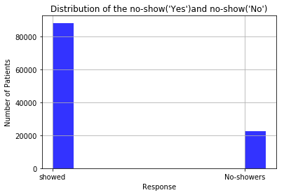

```python
#to show the distribution of the no-show('No')and no-show('Yes')
df['no_show'].hist(color='b',alpha=0.8)
plt.xlabel('Response')
plt.ylabel('Number of Patients')
plt.title("Distribution of the no-show('Yes')and no-show('No')")
plt.legend()
#plt.show()
plt.xticks([0,0.9],['showed','No-showers'])
```

The above distribution tells that generally,a higher number of patients didn't miss their appointment.

```python
#how many females showed-up and how many didn't
df_f = df.query('gender=="F"')
f = df_f['no_show'].value_counts()

#how many females showed-up and how many didn't
df_m = df.query('gender=="M"')
m = df_m['no_show'].value_counts()
print(f,m)
```

```
No     57246
Yes    14594
Name: no_show, dtype: int64 No     30962
Yes     7725
Name: no_show, dtype: int64
```

```
Text(0,0.5,'Show-up count')
```

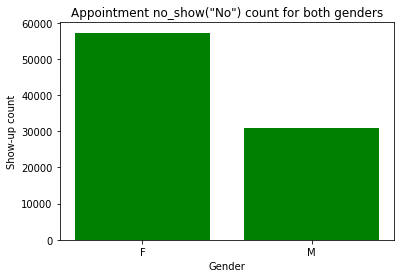

```python
plt.bar(['M','F'],[30962,57246], color='g')
plt.title('Appointment no_show("No") count for both genders')
plt.xlabel('Gender')
plt.ylabel('Show-up count')
```

From the barchart above,more females than males showed-up on their appointment date.

```
Text(0,0.5,'no_show count')
```

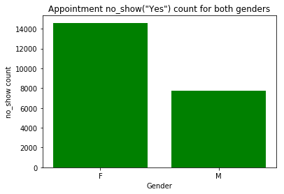

```python
plt.bar(['M','F'],[7725,14594], color='g')
plt.title('Appointment no_show("Yes") count for both genders')
plt.xlabel('Gender')
plt.ylabel('no_show count')
```

Also,the barchart above shows that more females than males didn't show-up on their appointment date.

*Below is a function I created in order to avoid repetitive coding, as I'll be finding proportional values twice - now and later.*

```python
# a function to calculate proportion when called upon.
def calc_proportion(x,y) :
    prop_x = (x*100)/(x+y)
    prop_x = "{:.2f}".format(prop_x)
    prop_y = (y*100)/(x+y)
    prop_y = "{:.2f}".format(prop_y)
    return{"no_show No-response" : prop_x+'%',"no_show Yes-response" : prop_y+'%'}
```

```python
#to call a function to get the proportion of 'yes/no' response in percentage for all the females.
calc_proportion(57246,14594)
```

```
{'no_show No-response': '79.69%', 'no_show Yes-response': '20.31%'}
```

From the result of the function call above, 79.69% of females in the dataset showed up for appointment, while 20.31% of females didn't.

```python
#to call a function to get the proportion of 'yes/no' responses in percentage for all the males.
calc_proportion(30962,7725)
```

```
{'no_show No-response': '80.03%', 'no_show Yes-response': '19.97%'}
```

From the result of the function call above, 80.03% of males in the dataset showed up for appointment, while 19.97% of males didn't.

### From my research above :

- The percentage of females that showed-up for appointment is higher than the females who didn't.
- The percentage of males that showed-up for appointment is also higher than the males who did not.
- Overall,more number of females showed-up for appointments than males.
- Likewise overall,more number of females did not show-up for appointments than males.

Therefore, there is not enough evidence to say that the patients' genders can be used to predict the outcome of showing up or not on the appointment days.

### Research Question 2 : What medical issues of patients are important inorder to predict whether a patient shows-up or not?

I'll be exploring 2 medical issues from the dataset,namely :

- hypertension,
- diabetes

I'm making this research to check if patients' appointment show-up is dependent on their personal medical issues.

The first medical issue I'll be researching on is Hypertension.

```
 <a list of 2 Text xticklabel objects>)
```

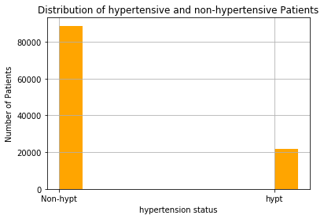

```python
df['hypertension'].hist(color='orange')
plt.title('Distribution of hypertensive and non-hypertensive Patients')
plt.xlabel('hypertension status')
plt.ylabel("Number of Patients")
plt.xticks([0,0.9],('Non-hypt','hypt'))
```

The bar chart distribution above shows that hypertensive patient are fewer in the dataset.

```python
#drop all rows with ['hipertension']==0
df_h = df[df['hypertension']==1]
df_h.head()
```

|  | patient_id | appointment_id | gender | scheduled_day | appointment_day | age | neighbourhood | scholarship | hypertension | diabetes | alcoholism | handicap | sms_received | no_show |
| --- | --- | --- | --- | --- | --- | --- | --- | --- | --- | --- | --- | --- | --- | --- |
| 0 | 2.987250e+13 | 5642903 | F | 2016-04-29T18:38:08Z | 2016-04-29T00:00:00Z | 62 | JARDIM DA PENHA | 0 | 1 | 0 | 0 | 0 | 0 | No |
| 4 | 8.841186e+12 | 5642494 | F | 2016-04-29T16:07:23Z | 2016-04-29T00:00:00Z | 56 | JARDIM DA PENHA | 0 | 1 | 1 | 0 | 0 | 0 | No |
| 5 | 9.598513e+13 | 5626772 | F | 2016-04-27T08:36:51Z | 2016-04-29T00:00:00Z | 76 | REPÚBLICA | 0 | 1 | 0 | 0 | 0 | 0 | No |
| 25 | 5.819370e+12 | 5624020 | M | 2016-04-26T15:04:17Z | 2016-04-29T00:00:00Z | 46 | CONQUISTA | 0 | 1 | 0 | 0 | 0 | 1 | No |
| 26 | 2.578785e+10 | 5641781 | F | 2016-04-29T14:19:42Z | 2016-04-29T00:00:00Z | 45 | BENTO FERREIRA | 0 | 1 | 0 | 0 | 0 | 0 | No |

The above dataset is uniquely for hypertensive patients, regardless whether they showed up or not on their appointment day

```python
#drop all rows with ['no-show']== "Yes"
df_h = df_h[df_h['no_show']=="No"]
```

```python
df_h.head()
```

|  | patient_id | appointment_id | gender | scheduled_day | appointment_day | age | neighbourhood | scholarship | hypertension | diabetes | alcoholism | handicap | sms_received | no_show |
| --- | --- | --- | --- | --- | --- | --- | --- | --- | --- | --- | --- | --- | --- | --- |
| 0 | 2.987250e+13 | 5642903 | F | 2016-04-29T18:38:08Z | 2016-04-29T00:00:00Z | 62 | JARDIM DA PENHA | 0 | 1 | 0 | 0 | 0 | 0 | No |
| 4 | 8.841186e+12 | 5642494 | F | 2016-04-29T16:07:23Z | 2016-04-29T00:00:00Z | 56 | JARDIM DA PENHA | 0 | 1 | 1 | 0 | 0 | 0 | No |
| 5 | 9.598513e+13 | 5626772 | F | 2016-04-27T08:36:51Z | 2016-04-29T00:00:00Z | 76 | REPÚBLICA | 0 | 1 | 0 | 0 | 0 | 0 | No |
| 25 | 5.819370e+12 | 5624020 | M | 2016-04-26T15:04:17Z | 2016-04-29T00:00:00Z | 46 | CONQUISTA | 0 | 1 | 0 | 0 | 0 | 1 | No |
| 26 | 2.578785e+10 | 5641781 | F | 2016-04-29T14:19:42Z | 2016-04-29T00:00:00Z | 45 | BENTO FERREIRA | 0 | 1 | 0 | 0 | 0 | 0 | No |

The above dataset is for all hypentensive patients that showed-up on their appointment date.

```python
df_h.shape
```

```
(18029, 14)
```

```python
df_h['no_show'].value_counts()
```

```
No    18029
Name: no_show, dtype: int64
```

```
Text(0.5,0,'Response')
```

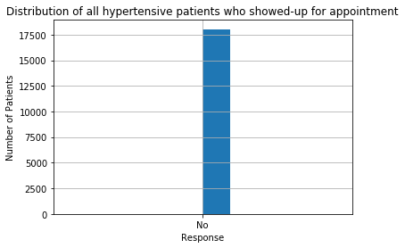

```python
df_h["no_show"].hist()
plt.title("Distribution of all hypertensive patients who showed-up for appointment")
plt.ylabel("Number of Patients")
plt.xlabel("Response")
```

The bar chart above shows the distribution of all hypertensive patients who showed-up on their medical appointment day.

I'll be showing the distribution of all hypertensive patients who didn't below.

```python
#drop all rows with ['hipertension']==0
df_h1 = df[df['hypertension']==1]
```

```python
#drop all rows with ['no-show']== "No"
df_h1 = df_h1[df_h1['no_show']=="Yes"]
```

```python
df_h1.head()
```

|  | patient_id | appointment_id | gender | scheduled_day | appointment_day | age | neighbourhood | scholarship | hypertension | diabetes | alcoholism | handicap | sms_received | no_show |
| --- | --- | --- | --- | --- | --- | --- | --- | --- | --- | --- | --- | --- | --- | --- |
| 44 | 2.741649e+11 | 5635414 | F | 2016-04-28T13:27:27Z | 2016-04-29T00:00:00Z | 78 | SÃO CRISTÓVÃO | 0 | 1 | 1 | 0 | 0 | 0 | Yes |
| 212 | 4.266984e+14 | 5642059 | M | 2016-04-29T14:59:38Z | 2016-04-29T00:00:00Z | 62 | SANTOS DUMONT | 0 | 1 | 1 | 0 | 0 | 0 | Yes |
| 270 | 8.617228e+12 | 5620528 | F | 2016-04-26T09:08:53Z | 2016-04-29T00:00:00Z | 45 | CARATOÍRA | 1 | 1 | 0 | 0 | 0 | 1 | Yes |
| 272 | 5.119616e+12 | 5594085 | F | 2016-04-18T10:12:57Z | 2016-04-29T00:00:00Z | 51 | NOVA PALESTINA | 0 | 1 | 0 | 0 | 1 | 1 | Yes |
| 352 | 5.917359e+12 | 5494413 | F | 2016-03-21T10:01:59Z | 2016-04-29T00:00:00Z | 62 | SÃO CRISTÓVÃO | 0 | 1 | 0 | 0 | 0 | 1 | Yes |

```python
df_h1.shape
```

```
(3772, 14)
```

```python
df_h1['no_show'].value_counts()
```

```
Yes    3772
Name: no_show, dtype: int64
```

```
Text(0,0.5,'Number of Hypertensive Patients')
```

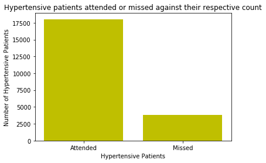

```python
plt.bar([1,2],[18029,3772],color='y')
plt.xticks([1,2],['Attended','Missed'])
plt.title('Hypertensive patients attended or missed against their respective count')
plt.xlabel('Hypertensive Patients')
plt.ylabel('Number of Hypertensive Patients')
```

### The whole research above shows that:

- 18,029 Hypertensive patients showed-up on their appointment date
- While, 3,772 Hypertensive patients did not show-up on their appointment date

Thus tentatively, these research shows that more hypentensive patients did not miss their appointment date.

### The next medical issue to research on is *diabetes*

The next few operations is intended to check if diabetes as a medical issue can be used to predict whether a patient shows-up or not on their appointment date

```python
#drop all rows with ['diabetes']==0
df_h2 = df[df['diabetes']==1]
df_h2.head()
```

|  | patient_id | appointment_id | gender | scheduled_day | appointment_day | age | neighbourhood | scholarship | hypertension | diabetes | alcoholism | handicap | sms_received | no_show |
| --- | --- | --- | --- | --- | --- | --- | --- | --- | --- | --- | --- | --- | --- | --- |
| 4 | 8.841186e+12 | 5642494 | F | 2016-04-29T16:07:23Z | 2016-04-29T00:00:00Z | 56 | JARDIM DA PENHA | 0 | 1 | 1 | 0 | 0 | 0 | No |
| 36 | 7.298459e+13 | 5637975 | F | 2016-04-29T07:35:19Z | 2016-04-29T00:00:00Z | 63 | SÃO CRISTÓVÃO | 0 | 1 | 1 | 0 | 0 | 0 | No |
| 37 | 1.578132e+12 | 5637986 | F | 2016-04-29T07:35:56Z | 2016-04-29T00:00:00Z | 64 | TABUAZEIRO | 1 | 1 | 1 | 0 | 0 | 0 | No |
| 41 | 8.224325e+14 | 5633339 | F | 2016-04-28T09:20:36Z | 2016-04-29T00:00:00Z | 71 | MARUÍPE | 0 | 0 | 1 | 0 | 0 | 0 | No |
| 44 | 2.741649e+11 | 5635414 | F | 2016-04-28T13:27:27Z | 2016-04-29T00:00:00Z | 78 | SÃO CRISTÓVÃO | 0 | 1 | 1 | 0 | 0 | 0 | Yes |

The above dataset is uniquely for *diabetes patients*, regardless *whether they showed up or not* on their appointment day

```python
#drop all rows with ['no-show']== "Yes"
df_h2 = df_h2[df_h2['no_show']=="No"]
```

```python
df_h2.head()
```

|  | patient_id | appointment_id | gender | scheduled_day | appointment_day | age | neighbourhood | scholarship | hypertension | diabetes | alcoholism | handicap | sms_received | no_show |
| --- | --- | --- | --- | --- | --- | --- | --- | --- | --- | --- | --- | --- | --- | --- |
| 4 | 8.841186e+12 | 5642494 | F | 2016-04-29T16:07:23Z | 2016-04-29T00:00:00Z | 56 | JARDIM DA PENHA | 0 | 1 | 1 | 0 | 0 | 0 | No |
| 36 | 7.298459e+13 | 5637975 | F | 2016-04-29T07:35:19Z | 2016-04-29T00:00:00Z | 63 | SÃO CRISTÓVÃO | 0 | 1 | 1 | 0 | 0 | 0 | No |
| 37 | 1.578132e+12 | 5637986 | F | 2016-04-29T07:35:56Z | 2016-04-29T00:00:00Z | 64 | TABUAZEIRO | 1 | 1 | 1 | 0 | 0 | 0 | No |
| 41 | 8.224325e+14 | 5633339 | F | 2016-04-28T09:20:36Z | 2016-04-29T00:00:00Z | 71 | MARUÍPE | 0 | 0 | 1 | 0 | 0 | 0 | No |
| 47 | 5.894585e+11 | 5633116 | F | 2016-04-28T08:51:26Z | 2016-04-29T00:00:00Z | 39 | MARUÍPE | 0 | 1 | 1 | 0 | 0 | 0 | No |

The above dataset is *only for diabetes* patients that *showed-up on their appointment date.*

```python
df_h2.shape
```

```
(6513, 14)
```

```python
df_h2['no_show'].value_counts()
```

```
No    6513
Name: no_show, dtype: int64
```

Only 6,513 patients who have *diabetes* showed-up on their appointment date.

Below is the research for count of patients who also have diabetes *but didn't show-up on their appointment day.*

```python
#drop all rows with ['diabetes']==0
df_h2 = df[df['diabetes']==1]
df_h2.head()
```

|  | patient_id | appointment_id | gender | scheduled_day | appointment_day | age | neighbourhood | scholarship | hypertension | diabetes | alcoholism | handicap | sms_received | no_show |
| --- | --- | --- | --- | --- | --- | --- | --- | --- | --- | --- | --- | --- | --- | --- |
| 4 | 8.841186e+12 | 5642494 | F | 2016-04-29T16:07:23Z | 2016-04-29T00:00:00Z | 56 | JARDIM DA PENHA | 0 | 1 | 1 | 0 | 0 | 0 | No |
| 36 | 7.298459e+13 | 5637975 | F | 2016-04-29T07:35:19Z | 2016-04-29T00:00:00Z | 63 | SÃO CRISTÓVÃO | 0 | 1 | 1 | 0 | 0 | 0 | No |
| 37 | 1.578132e+12 | 5637986 | F | 2016-04-29T07:35:56Z | 2016-04-29T00:00:00Z | 64 | TABUAZEIRO | 1 | 1 | 1 | 0 | 0 | 0 | No |
| 41 | 8.224325e+14 | 5633339 | F | 2016-04-28T09:20:36Z | 2016-04-29T00:00:00Z | 71 | MARUÍPE | 0 | 0 | 1 | 0 | 0 | 0 | No |
| 44 | 2.741649e+11 | 5635414 | F | 2016-04-28T13:27:27Z | 2016-04-29T00:00:00Z | 78 | SÃO CRISTÓVÃO | 0 | 1 | 1 | 0 | 0 | 0 | Yes |

```python
#drop all rows with ['no-show']== "No"
df_h2 = df_h2[df_h2['no_show']=="Yes"]
```

```python
df_h2.head()
```

|  | patient_id | appointment_id | gender | scheduled_day | appointment_day | age | neighbourhood | scholarship | hypertension | diabetes | alcoholism | handicap | sms_received | no_show |
| --- | --- | --- | --- | --- | --- | --- | --- | --- | --- | --- | --- | --- | --- | --- |
| 44 | 2.741649e+11 | 5635414 | F | 2016-04-28T13:27:27Z | 2016-04-29T00:00:00Z | 78 | SÃO CRISTÓVÃO | 0 | 1 | 1 | 0 | 0 | 0 | Yes |
| 126 | 9.447582e+14 | 5633576 | F | 2016-04-28T09:37:22Z | 2016-04-29T00:00:00Z | 67 | PRAIA DO SUÁ | 0 | 0 | 1 | 0 | 0 | 0 | Yes |
| 212 | 4.266984e+14 | 5642059 | M | 2016-04-29T14:59:38Z | 2016-04-29T00:00:00Z | 62 | SANTOS DUMONT | 0 | 1 | 1 | 0 | 0 | 0 | Yes |
| 463 | 5.228864e+08 | 5633872 | F | 2016-04-28T09:58:32Z | 2016-04-29T00:00:00Z | 66 | SÃO CRISTÓVÃO | 0 | 1 | 1 | 0 | 0 | 0 | Yes |
| 619 | 4.272659e+13 | 5634178 | F | 2016-04-28T10:30:27Z | 2016-04-29T00:00:00Z | 67 | PRAIA DO CANTO | 0 | 1 | 1 | 0 | 0 | 0 | Yes |

The above dataset is only for *diabetes patients* that *didn't show-up* on their appointment date.

```python
df_h2.shape
```

```
(1430, 14)
```

```python
df_h2["no_show"].value_counts()
```

```
Yes    1430
Name: no_show, dtype: int64
```

The above operations reveals that 1,430 patients who have *diabetes* didn't show-up on their appointment date.

```
Text(0,0.5,'Number of Diabetic Patients')
```

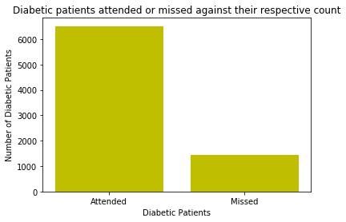

```python
plt.bar([1,2],[6513,1430],color='y')
plt.xticks([1,2],['Attended','Missed'])
plt.title('Diabetic patients attended or missed against their respective count')
plt.xlabel('Diabetic Patients')
plt.ylabel('Number of Diabetic Patients')
```

### The whole research on diabetes above shows that:

- 6,513 diabetic patients showed-up on their appointment date
- While, 1,430 diabetic patients did not show-up on their appointment date

Thus tentatively, this research shows that more diabetic patients did not miss their appointment date.

# Conclusions

## Results :

1. I checked if gender was a depending factor for no-show response received from patients,by carrying out operations to know how many females missed their appointments and how many didn't, how many males missed their appointments and how many didn't. The result of my findings showed that more females than males actually missed, and not missed their medical appointments. However, there are limitations to my research,thus this result is not sufficient to strongly say that gender is truly not a depending factor for the no-show responses.
1. I also checked if medical issues are also a depending factor for no-show response received from patients. The result of my findings shows that there are much higher number of hypertensive/diabetic patients who didn't miss their medical appointment. Due to the limitations in my findings, there are not enough evidences for me to strongly state that these medical issues(Hypertension and Diabetes) are actually enough to predict the no-show responses observed from the patients in the dataset.

## Limitations:

1. I observed that some patients are neither enrolled on scholarship, and they also have all zero "0" value for the following column headers: "alcohol","diabetes","handicap", but they showed up on their appointment date. The question is,what could have brought them to the hospital in the first place? I could dive deeper into analysis with additional information, but were not gven in the dataset.
1. I couldn't show strong correlations because most of the column headers have categorical values, e.g "alcohol","diabetes","handicap","scholarship" all having 0 or 1 values, and the "no_show" with a "Yes" or "No".

```python
from subprocess import call
call(['python', '-m', 'nbconvert', 'investigate_a_dataset.ipynb'])
```

```
255
```